PA_1_repdata-016 author: “Donhirst” date: “December 8, 2014” output: html_document —

This is an R Markdown document written for the Coursera course on Reproducible Research, repdata-16, Dec 2014. The data set is from a collection of personal activity data,“activity.csv”, recorded by personal fitness devices and may be found at:

```
            https://d396qusza40orc.cloudfront.net/repdata%2Fdata%2Factivity.zip
```

The data consists of two months of data from an anonymous individual collected during the months of October and November, 2012 and include the number of steps taken in 5 minute intervals each day. To run the script the data should be downloaded to the working directory. The variables included in this dataset are:

steps: Number of steps taking in a 5-minute interval (missing values are coded as NA)

date: The date on which the measurement was taken in YYYY-MM-DD format

interval: Identifier for the 5-minute interval in which measurement was taken

steps date interval 1 NA 2012-10-01 0 2 NA 2012-10-01 5 3 NA 2012-10-01 10 4 NA 2012-10-01 15 5 NA 2012-10-01 20 6 NA 2012-10-01 25

```r
library(plyr)
library(lattice)
```

The data are read in:

```r
personal_data <- read.csv("activity.csv", header = TRUE)
```

Only the first two columns (steps and date) are needed for the first part of this assignment.

```r
personal_steps <- personal_data[,1:2]
```

Make a histogram of the number of steps per day

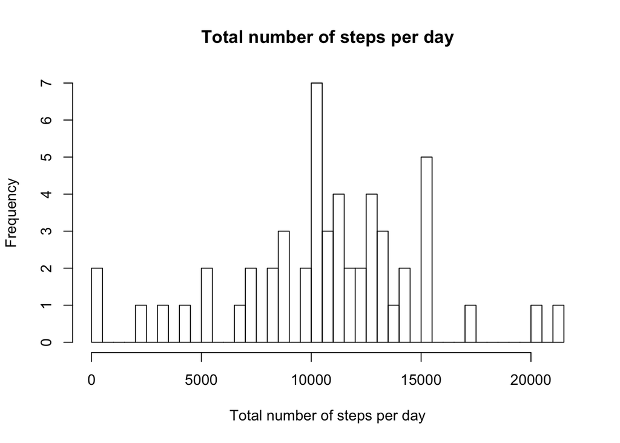

```r
total_steps <- aggregate(.~ date, data = personal_steps, sum)
hist(total_steps$steps, breaks = nrow(total_steps)-1, xlab= "Total number of steps per day", main = "Total number of steps per day")
```

Find the mean and median total number of steps/day

```r
mean_steps <- mean(total_steps$steps)
sprintf("The mean of the total steps per day = %f", mean_steps)
```

```
## [1] "The mean of the total steps per day = 10766.188679"
```

```r
median_steps <- median(total_steps$steps)
sprintf("The median of the total steps per day = %f", median_steps)
```

```
## [1] "The median of the total steps per day = 10765.000000"
```

The next task is to find the average daily activity pattern. The following r code plots the 5-minute time interval (x-axis) vs the average number of steps taken averaged across all days (y-axis). Only the first (steps) and third (interval)columns are needed.

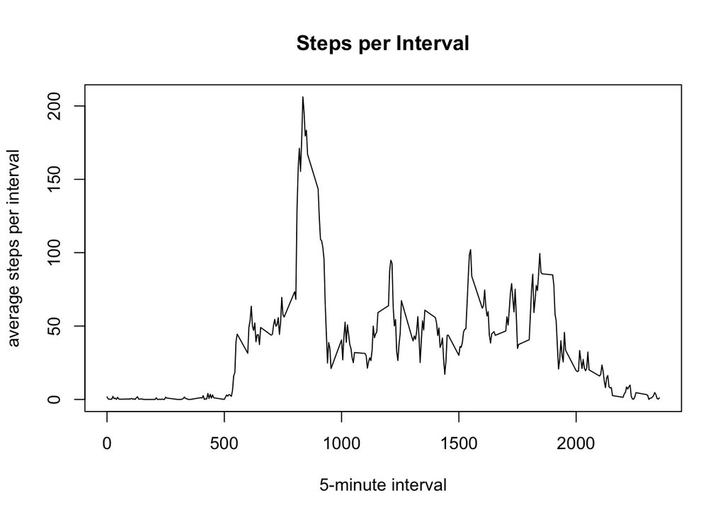

```r
average_steps <- personal_data[,c(1,3)]
interval_steps <- aggregate(.~ interval, data = average_steps, mean)
plot(interval_steps$interval, interval_steps$steps, type = "l", xlab = "5-minute interval", ylab = "average steps per interval", main = "Steps per Interval")
```

Find the maximum number of steps and the interval in which they occur.

```r
max_steps <- max(interval_steps$steps)
sprintf("The maximum number of steps per interval is %f ", max_steps)
```

```
## [1] "The maximum number of steps per interval is 206.169811 "
```

```r
interval_max_steps <- subset(interval_steps, steps == max_steps)
sprintf("The interval containing the maximum number of steps is %i",interval_max_steps[,1])
```

```
## [1] "The interval containing the maximum number of steps is 835"
```

Up to now, missing numbers (NAs) have been ignored. A question arises if these missing values could introduce bias into the results or calculations. One way to deal with this would be to develop a (dubious) strategy of somehow inventing numbers to stand for the missing ones. This seems a very questionable proceedure but as this is a requirement for this exercise it has to be done.

First the number of rows of the original data set with NAs is calculated.

```r
number_rows_noNAs <- sum(is.na(personal_data$steps))
sprintf("The number of rows with no NAs is: %i", number_rows_noNAs)
```

[output not shown]

Now to figure out how to fill in the NAs with sythesized (fake) numbers. The means for steps per day and per interval are available or easily calculated from the r code above. The following code adds a column (new_steps) to the orginal data frame (personal_data) which is the average number of steps for each interval

```r
new_mean_steps <-tapply(personal_data$steps, personal_data$interval, mean, na.rm = TRUE)
new_mean_steps <- as.data.frame(new_mean_steps)

for(i in 1:nrow(personal_data)){

  if (is.na(personal_data[i,1])) {

                         j <- personal_data$interval[i]
                         j = as.character(j)
                       interval_mean <- new_mean_steps[j,1]
                       personal_data[i,1] <- interval_mean

  }
}
```

Only the first two columns (steps and date) are needed for the first part of this assignment.

```r
personal_steps <- personal_data[,1:2]
```

Make a histogram of the number of steps per day from the imputed data

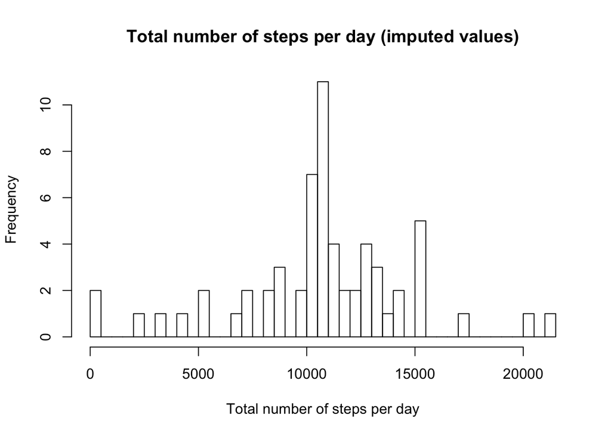

```r
imputed_total_steps <- aggregate(.~ date, data = personal_steps, sum)
hist(imputed_total_steps$steps, breaks = nrow(total_steps)-1, xlab= "Total number of steps per day", main = "Total number of steps per day (imputed values)")
```

Find the mean and median total number of steps/day for the imputed data

```r
imputed_mean_steps <- mean(imputed_total_steps$steps)
sprintf("The mean of the total steps per day (imputed values) = %f", imputed_mean_steps)
```

```
## [1] "The mean of the total steps per day (imputed values) = 10766.188679"
```

```r
imputed_median_steps <- median(imputed_total_steps$steps)
sprintf("The median of the total steps per day (imputed values) = %f", imputed_median_steps)
```

```
## [1] "The median of the total steps per day (imputed values) = 10766.188679"
```

```r
mean_diff<- imputed_mean_steps - mean_steps
sprintf("The difference between the imputed mean and the original mean is: %f", mean_diff)
```

```
## [1] "The difference between the imputed mean and the original mean is: 0.000000"
```

```r
median_diff <- imputed_median_steps - median_steps
sprintf("The difference between the imputed median and the original median is: %f", median_diff)
```

```
## [1] "The difference between the imputed median and the original median is: 1.188679"
```

The fact that the means are the same is not too suprising since the mean for each interval was used to replace the NAs in the data set. The difference in the medians is expected since it would be unlikely that the imputed data would be optimized for both the mean and median. Nevertheless the difference compared to the maximum is about 0.01 %. The conclusion is that the impact is minimal.

The next task is to investigate the difference between activity on weekdays and on weekend using the imputed data set.

First, as the date values of the data file are factors they need to be changed into class “date.” Second a new variable (column), week, will be added to the imputed data frame. Produce two character strings: “weekend” and “weekday.” Condense “day_of_week” variable into two levels: “weekend” and “weekday.”

```r
personal_data$date <- as.Date(personal_data$date)
personal_data <- mutate(personal_data, day_of_week = weekdays(personal_data$date))
weekday <- c("Monday", "Tuesday", "Wednesday", "Thursday", "Friday")
weekend <- c("Saturday", "Sunday")
personal_data$day_of_week <- as.factor(personal_data$day_of_week)
levels(personal_data$day_of_week)<- list(weekday = weekday, weekend = weekend)
```

Now to make a panel plot. This will be a time series plot of the 5 minute intervals (x-axis) vs the average number of steps taken (y-axis) averaged over all weekdays or weekends. First, get rid of the “date” column which is of no interest. Second the average is taken for each interval and week level (weekend or weekday). Aggregate trashes the headers so the headers are renamed to something meaningful. Finally, we plot with a panel plot with xyplot

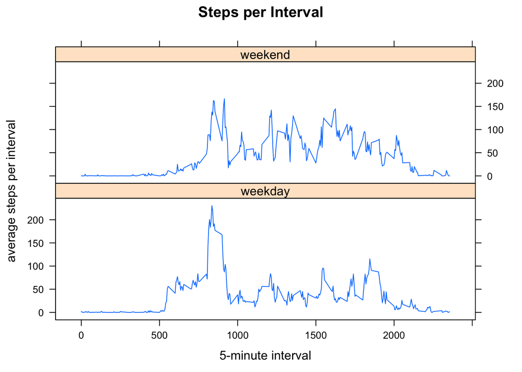

```r
week_average_steps <- personal_data[,c(1,3,4)]
week_interval_steps <- aggregate(week_average_steps$steps, list(week_average_steps$interval,week_average_steps$day_of_week), mean)
names(week_interval_steps)<- c("interval", "week_level", "mean_steps")

means_plot<-xyplot (mean_steps~ interval | week_level, data = week_interval_steps, layout = c(1,2), xlab = "5-minute interval", ylab = "average steps per interval",
        main = "Steps per Interval", type = "l")
print(means_plot)
```